# DAT402Proj2

William Reid

2026-05-03

Introduction

This project uses machine learning to predict a Pokemon’s primary type based on its stats, height, weight, and base experience.

The goal is to compare multiple machine learning models and determine which model performs best at classifying Pokemon types.

Dataset Description

```r
data <- read.csv("pokemon_data.csv")

head(data)
```

```
##   id       name base_experience height weight         types
## 1  1  bulbasaur              64      7     69 grass, poison
## 2  2    ivysaur             142     10    130 grass, poison
## 3  3   venusaur             236     20   1000 grass, poison
## 4  4 charmander              62      6     85          fire
## 5  5 charmeleon             142     11    190          fire
## 6  6  charizard             240     17    905  fire, flying
##               abilities
## 1 overgrow, chlorophyll
## 2 overgrow, chlorophyll
## 3 overgrow, chlorophyll
## 4    blaze, solar-power
## 5    blaze, solar-power
## 6    blaze, solar-power
##                                                          moves
## 1               razor-wind, swords-dance, cut, bind, vine-whip
## 2                 swords-dance, cut, bind, vine-whip, headbutt
## 3                 swords-dance, cut, bind, vine-whip, headbutt
## 4 mega-punch, fire-punch, thunder-punch, scratch, swords-dance
## 5 mega-punch, fire-punch, thunder-punch, scratch, swords-dance
## 6 mega-punch, fire-punch, thunder-punch, scratch, swords-dance
##                                                                             stats
## 1   hp=45, attack=49, defense=49, special-attack=65, special-defense=65, speed=45
## 2   hp=60, attack=62, defense=63, special-attack=80, special-defense=80, speed=60
## 3 hp=80, attack=82, defense=83, special-attack=100, special-defense=100, speed=80
## 4   hp=39, attack=52, defense=43, special-attack=60, special-defense=50, speed=65
## 5   hp=58, attack=64, defense=58, special-attack=80, special-defense=65, speed=80
## 6 hp=78, attack=84, defense=78, special-attack=109, special-defense=85, speed=100
```

```r
str(data)
```

```
## 'data.frame':    1302 obs. of  9 variables:
##  $ id             : int  1 2 3 4 5 6 7 8 9 10 ...
##  $ name           : chr  "bulbasaur" "ivysaur" "venusaur" "charmander" ...
##  $ base_experience: int  64 142 236 62 142 240 63 142 239 39 ...
##  $ height         : int  7 10 20 6 11 17 5 10 16 3 ...
##  $ weight         : int  69 130 1000 85 190 905 90 225 855 29 ...
##  $ types          : chr  "grass, poison" "grass, poison" "grass, poison" "fire" ...
##  $ abilities      : chr  "overgrow, chlorophyll" "overgrow, chlorophyll" "overgrow, chlorophyll" "blaze, solar-power" ...
##  $ moves          : chr  "razor-wind, swords-dance, cut, bind, vine-whip" "swords-dance, cut, bind, vine-whip, headbutt" "swords-dance, cut, bind, vine-whip, headbutt" "mega-punch, fire-punch, thunder-punch, scratch, swords-dance" ...
##  $ stats          : chr  "hp=45, attack=49, defense=49, special-attack=65, special-defense=65, speed=45" "hp=60, attack=62, defense=63, special-attack=80, special-defense=80, speed=60" "hp=80, attack=82, defense=83, special-attack=100, special-defense=100, speed=80" "hp=39, attack=52, defense=43,…
```

```r
summary(data)
```

```
##        id                 name      base_experience     height
##  Min.   :    1.0   Length   :1302   Min.   : 36.0   Min.   :   1.00
##  1st Qu.:  326.2   N.unique :1302   1st Qu.: 71.0   1st Qu.:   5.00
##  Median :  651.5   N.blank  :   0   Median :165.0   Median :  10.00
##  Mean   : 2560.9   Min.nchar:   3   Mean   :161.9   Mean   :  20.47
##  3rd Qu.:  976.8   Max.nchar:  39   3rd Qu.:222.5   3rd Qu.:  16.00
##  Max.   :10277.0                    Max.   :608.0   Max.   :1000.00
##      weight               types          abilities          moves
##  Min.   :    0.00   Length   :1302   Length   :1302   Length   :1302
##  1st Qu.:   89.25   N.unique : 221   N.unique : 707   N.unique : 813
##  Median :  315.50   N.blank  :   0   N.blank  :   0   N.blank  :  34
##  Mean   :  980.86   Min.nchar:   3   Min.nchar:   5   Min.nchar:   0
##  3rd Qu.:  818.00   Max.nchar:  18   Max.nchar:  42   Max.nchar:  64
##  Max.   :10000.00
##        stats
##  Length   :1302
##  N.unique :1142
##  N.blank  :   0
##  Min.nchar:  76
##  Max.nchar:  83
##
```

Data Cleaning

```r
data_clean <- data %>%
  separate(
    stats,
    into = c("hp", "attack", "defense", "special_attack", "special_defense", "speed"),
    sep = ", "
  ) %>%
  mutate(
    hp = as.numeric(gsub("hp=", "", hp)),
    attack = as.numeric(gsub("attack=", "", attack)),
    defense = as.numeric(gsub("defense=", "", defense)),
    special_attack = as.numeric(gsub("special-attack=", "", special_attack)),
    special_defense = as.numeric(gsub("special-defense=", "", special_defense)),
    speed = as.numeric(gsub("speed=", "", speed)),
    primary_type = sapply(strsplit(types, ", "), `[`, 1),
    primary_type = as.factor(primary_type)
  ) %>%
  na.omit()

str(data_clean)
```

```
## 'data.frame':    1302 obs. of  15 variables:
##  $ id             : int  1 2 3 4 5 6 7 8 9 10 ...
##  $ name           : chr  "bulbasaur" "ivysaur" "venusaur" "charmander" ...
##  $ base_experience: int  64 142 236 62 142 240 63 142 239 39 ...
##  $ height         : int  7 10 20 6 11 17 5 10 16 3 ...
##  $ weight         : int  69 130 1000 85 190 905 90 225 855 29 ...
##  $ types          : chr  "grass, poison" "grass, poison" "grass, poison" "fire" ...
##  $ abilities      : chr  "overgrow, chlorophyll" "overgrow, chlorophyll" "overgrow, chlorophyll" "blaze, solar-power" ...
##  $ moves          : chr  "razor-wind, swords-dance, cut, bind, vine-whip" "swords-dance, cut, bind, vine-whip, headbutt" "swords-dance, cut, bind, vine-whip, headbutt" "mega-punch, fire-punch, thunder-punch, scratch, swords-dance" ...
##  $ hp             : num  45 60 80 39 58 78 44 59 79 45 ...
##  $ attack         : num  49 62 82 52 64 84 48 63 83 30 ...
##  $ defense        : num  49 63 83 43 58 78 65 80 100 35 ...
##  $ special_attack : num  65 80 100 60 80 109 50 65 85 20 ...
##  $ special_defense: num  65 80 100 50 65 85 64 80 105 20 ...
##  $ speed          : num  45 60 80 65 80 100 43 58 78 45 ...
##  $ primary_type   : Factor w/ 18 levels "bug","dark","dragon",..: 10 10 10 7 7 7 18 18 18 1 ...
```

```r
summary(data_clean)
```

```
##        id                 name      base_experience     height
##  Min.   :    1.0   Length   :1302   Min.   : 36.0   Min.   :   1.00
##  1st Qu.:  326.2   N.unique :1302   1st Qu.: 71.0   1st Qu.:   5.00
##  Median :  651.5   N.blank  :   0   Median :165.0   Median :  10.00
##  Mean   : 2560.9   Min.nchar:   3   Mean   :161.9   Mean   :  20.47
##  3rd Qu.:  976.8   Max.nchar:  39   3rd Qu.:222.5   3rd Qu.:  16.00
##  Max.   :10277.0                    Max.   :608.0   Max.   :1000.00
##
##      weight               types          abilities          moves
##  Min.   :    0.00   Length   :1302   Length   :1302   Length   :1302
##  1st Qu.:   89.25   N.unique : 221   N.unique : 707   N.unique : 813
##  Median :  315.50   N.blank  :   0   N.blank  :   0   N.blank  :  34
##  Mean   :  980.86   Min.nchar:   3   Min.nchar:   5   Min.nchar:   0
##  3rd Qu.:  818.00   Max.nchar:  18   Max.nchar:  42   Max.nchar:  64
##  Max.   :10000.00
##
##        hp             attack          defense       special_attack
##  Min.   :  1.00   Min.   :  5.00   Min.   :  5.00   Min.   : 10.00
##  1st Qu.: 54.00   1st Qu.: 58.00   1st Qu.: 53.00   1st Qu.: 50.00
##  Median : 70.00   Median : 80.00   Median : 70.00   Median : 65.00
##  Mean   : 71.31   Mean   : 81.59   Mean   : 75.24   Mean   : 73.67
##  3rd Qu.: 85.00   3rd Qu.:100.00   3rd Qu.: 95.00   3rd Qu.: 95.00
##  Max.   :255.00   Max.   :190.00   Max.   :250.00   Max.   :194.00
##
##  special_defense      speed          primary_type
##  Min.   : 20.00   Min.   :  5.00   water   :157
##  1st Qu.: 52.00   1st Qu.: 48.00   normal  :138
##  Median : 70.00   Median : 70.00   grass   :118
##  Mean   : 72.97   Mean   : 71.16   electric: 96
##  3rd Qu.: 90.00   3rd Qu.: 92.00   bug     : 93
##  Max.   :250.00   Max.   :200.00   psychic : 83
##                                    (Other) :617
```

# Exploratory Data Analysis

Type Distribution

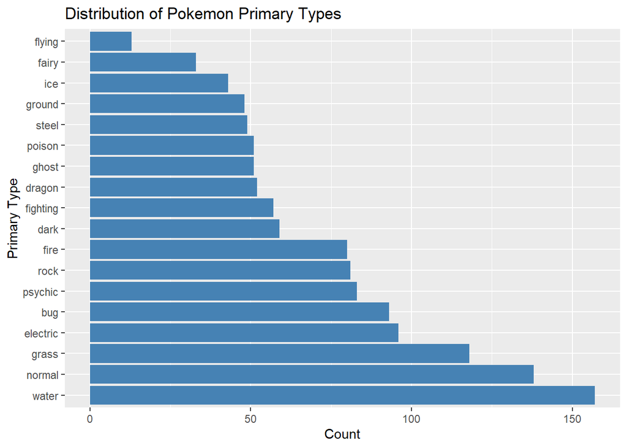

```r
ggplot(data_clean, aes(x = fct_infreq(primary_type))) +
  geom_bar(fill = "steelblue") +
  coord_flip() +
  labs(
    title = "Distribution of Pokemon Primary Types",
    x = "Primary Type",
    y = "Count"
  )
```

Attack vs Speed

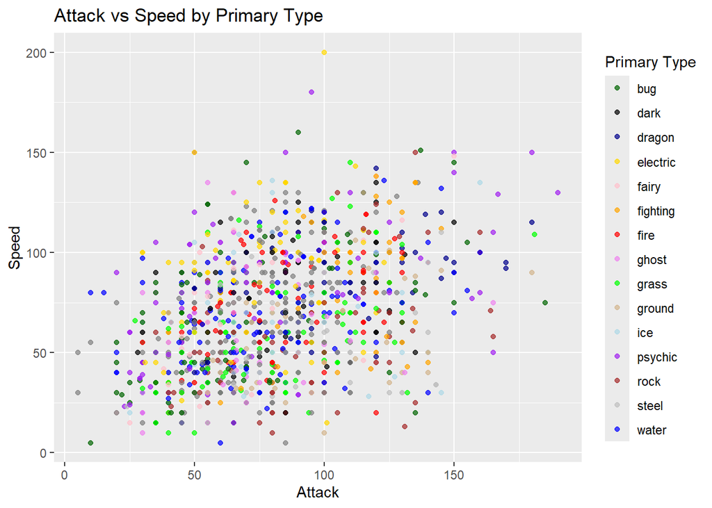

```r
## Attack vs Speed by Type (Custom colors)

ggplot(data_clean, aes(x = attack, y = speed, color = primary_type)) +
  geom_point(alpha = 0.7) +
  scale_color_manual(values = c(
    "fire" = "red",
    "water" = "blue",
    "grass" = "green",
    "electric" = "gold",
    "psychic" = "purple",
    "rock" = "brown",
    "ground" = "tan",
    "ice" = "lightblue",
    "dragon" = "darkblue",
    "dark" = "black",
    "fairy" = "pink",
    "fighting" = "orange",
    "ghost" = "violet",
    "bug" = "darkgreen",
    "steel" = "gray"
  )) +
  labs(
    title = "Attack vs Speed by Primary Type",
    x = "Attack",
    y = "Speed",
    color = "Primary Type"
  )
```

Stats by Primary Type

```r
data_long <- data_clean %>%
  select(primary_type, hp, attack, defense, special_attack, special_defense, speed) %>%
  pivot_longer(
    cols = c(hp, attack, defense, special_attack, special_defense, speed),
    names_to = "stat",
    values_to = "value"
  )
```

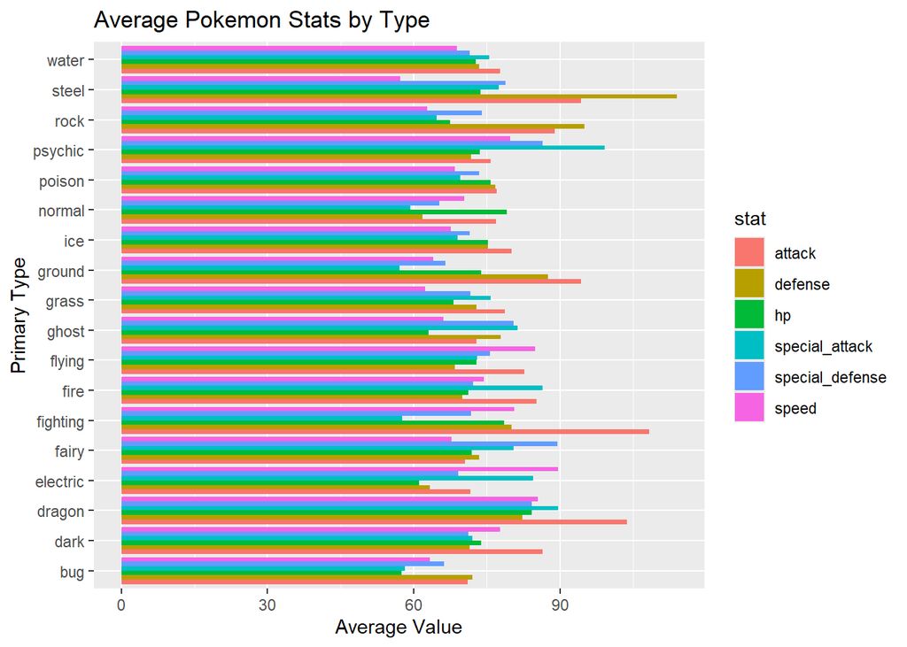

```r
avg_stats <- data_long %>%
  group_by(primary_type, stat) %>%
  summarise(mean_value = mean(value), .groups = "drop")

ggplot(avg_stats, aes(x = primary_type, y = mean_value, fill = stat)) +
  geom_col(position = "dodge") +
  coord_flip() +
  labs(
    title = "Average Pokemon Stats by Type",
    x = "Primary Type",
    y = "Average Value"
  )
```

Unsupervised Learning (PCA)

```r
numeric_data <- data_clean %>%
  select(hp, attack, defense, special_attack, special_defense, speed)

scaled_data <- scale(numeric_data)

pca_model <- prcomp(scaled_data)

summary(pca_model)
```

```
## Importance of components:
##                           PC1    PC2    PC3    PC4     PC5    PC6
## Standard deviation     1.6502 1.0496 0.9098 0.8046 0.65621 0.5190
## Proportion of Variance 0.4539 0.1836 0.1380 0.1079 0.07177 0.0449
## Cumulative Proportion  0.4539 0.6375 0.7754 0.8833 0.95510 1.0000
```

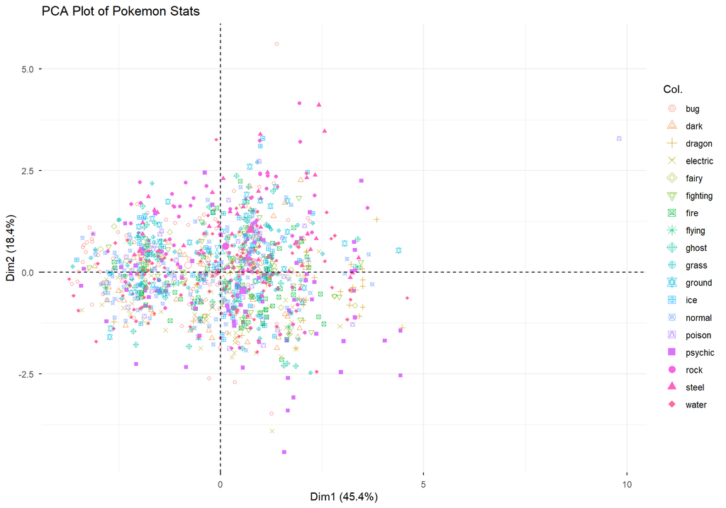

```r
fviz_pca_ind(
  pca_model,
  geom = "point",
  col.ind = data_clean$primary_type,
  title = "PCA Plot of Pokemon Stats"
)
```

Train/Test Split

```r
set.seed(123)

train_index <- createDataPartition(data_clean$primary_type, p = 0.7, list = FALSE)

train <- data_clean[train_index, ]
test <- data_clean[-train_index, ]
```

Model 1: Decision Tree

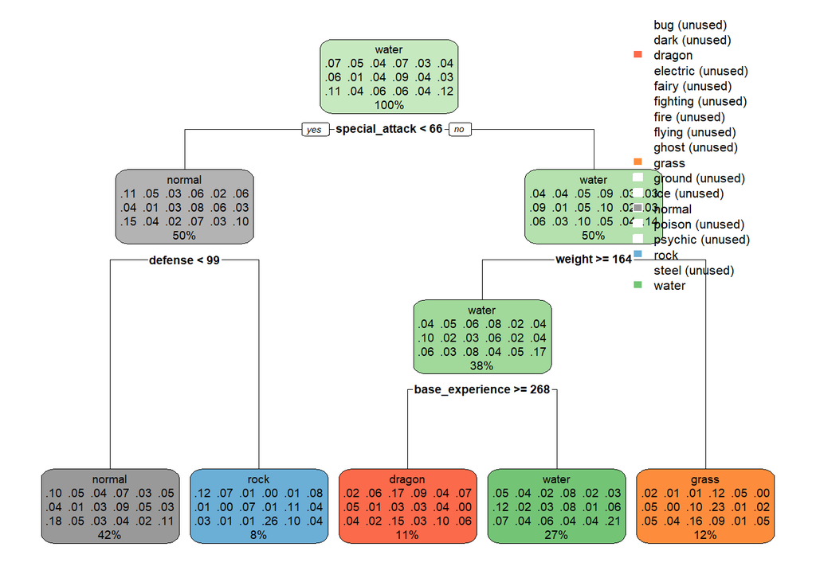

```r
tree_model <- rpart(primary_type ~ hp + attack + defense + special_attack + special_defense + speed + height + weight + base_experience,
                    data = train,
                    method = "class")

rpart.plot(tree_model)
```

```r
tree_pred <- predict(tree_model, test, type = "class")

tree_cm <- confusionMatrix(tree_pred, test$primary_type)
tree_cm
```

```
## Confusion Matrix and Statistics
##
##           Reference
## Prediction bug dark dragon electric fairy fighting fire flying ghost grass
##   bug        0    0      0        0     0        0    0      0     0     0
##   dark       0    0      0        0     0        0    0      0     0     0
##   dragon     0    3      8        2     0        2    2      0     1     2
##   electric   0    0      0        0     0        0    0      0     0     0
##   fairy      0    0      0        0     0        0    0      0     0     0
##   fighting   0    0      0        0     0        0    0      0     0     0
##   fire       0    0      0        0     0        0    0      0     0     0
##   flying     0    0      0        0     0        0    0      0     0     0
##   ghost      0    0      0        0     0        0    0      0     0     0
##   grass      6    4      2        4     3        0    1      0     4     2
##   ground     0    0      0        0     0        0    0      0     0     0
##   ice        0    0      0        0     0        0    0      0     0     0
##   normal    12    5      4       10     2       11    7      0     6    15
##   poison     0    0      0        0     0        0    0      0     0     0
##   psychic    0    0      0        0     0        0    0      0     0     0
##   rock       5    2      0        0     1        2    2      2     3     2
##   steel      0    0      0        0     0        0    0      0     0     0
##   water      4    3      1       12     3        2   12      1     1    14
##           Reference
## Prediction ground ice normal poison psychic rock steel water
##   bug           0   0      0      0       0    0     0     0
##   dark          0   0      0      0       0    0     0     0
##   dragon        2   0      0      0       6    2     2     3
##   electric      0   0      0      0       0    0     0     0
##   fairy         0   0      0      0       0    0     0     0
##   fighting      0   0      0      0       0    0     0     0
##   fire          0   0      0      0       0    0     0     0
##   flying        0   0      0      0       0    0     0     0
##   ghost         0   0      0      0       0    0     0     0
##   grass         0   1      1      3       5    1     1     3
##   ground        0   0      0      0       0    0     0     0
##   ice           0   0      0      0       0    0     0     0
##   normal        5   5     30      6       6    7     1    19
##   poison        0   0      0      0       0    0     0     0
##   psychic       0   0      0      0       0    0     0     0
##   rock          5   2      1      2       0   10     7     4
```

[output cut: 46 more lines]

```
## Pos Pred Value             0.19868           NaN            NaN     0.20000
## Neg Pred Value             0.95217       0.96063        0.93701     0.95770
## Prevalence                 0.10761       0.03937        0.06299     0.06299
## Detection Rate             0.07874       0.00000        0.00000     0.02625
## Detection Prevalence       0.39633       0.00000        0.00000     0.13123
## Balanced Accuracy          0.68791       0.50000        0.50000     0.65231
##                      Class: steel Class: water
## Sensitivity               0.00000      0.38298
## Specificity               1.00000      0.74251
## Pos Pred Value                NaN      0.17308
## Neg Pred Value            0.96325      0.89531
## Prevalence                0.03675      0.12336
## Detection Rate            0.00000      0.04724
## Detection Prevalence      0.00000      0.27297
## Balanced Accuracy         0.50000      0.56275
```

Model 2: Random Forest

```r
set.seed(123)

rf_model <- randomForest(
  primary_type ~ hp + attack + defense + special_attack + special_defense + speed + height + weight + base_experience,
  data = train,
  ntree = 500,
  importance = TRUE
)

rf_pred <- predict(rf_model, test)

rf_cm <- confusionMatrix(rf_pred, test$primary_type)
rf_cm
```

```
## Confusion Matrix and Statistics
##
##           Reference
## Prediction bug dark dragon electric fairy fighting fire flying ghost grass
##   bug       10    1      0        1     1        0    1      0     1     3
##   dark       0    2      0        0     0        1    0      1     0     0
##   dragon     0    1     10        1     0        1    1      0     0     0
##   electric   2    2      0       16     1        0    0      0     1     1
##   fairy      0    0      0        0     0        0    0      0     0     0
##   fighting   0    0      1        0     0        7    0      0     0     1
##   fire       2    1      0        1     0        1   12      0     0     2
##   flying     0    0      0        0     0        0    0      1     0     0
##   ghost      0    0      0        1     0        0    1      0     4     1
##   grass      4    1      1        1     4        1    2      0     2     7
##   ground     0    0      0        0     0        1    0      0     0     0
##   ice        0    0      0        0     0        0    1      0     0     0
##   normal     5    5      2        0     1        3    1      0     0     2
##   poison     0    0      0        0     0        0    0      0     0     0
##   psychic    0    1      0        4     1        0    2      0     4     1
##   rock       3    0      0        0     0        2    0      0     0     1
##   steel      1    0      0        0     0        0    1      0     1     0
##   water      0    3      1        3     1        0    2      1     2    16
##           Reference
## Prediction ground ice normal poison psychic rock steel water
##   bug           3   0      5      1       1    1     3     2
##   dark          1   0      1      1       1    1     0     1
##   dragon        2   0      0      0       1    1     0     2
##   electric      0   0      0      1       1    0     0     4
##   fairy         0   0      0      0       1    0     0     0
##   fighting      1   0      2      0       0    0     0     0
##   fire          1   2      1      0       3    0     1     4
##   flying        0   0      0      0       0    0     0     0
##   ghost         0   0      0      0       0    0     1     0
##   grass         0   0      3      1       4    2     1     4
##   ground        1   1      0      0       0    2     0     2
##   ice           0   2      0      0       1    0     0     0
##   normal        1   1     19      2       0    1     0     4
##   poison        0   0      0      3       0    1     0     0
##   psychic       1   1      1      1       6    1     0     1
##   rock          0   1      1      1       1    9     4     3
```

[output cut: 46 more lines]

```
## Pos Pred Value             0.40426      0.750000        0.24000     0.34615
## Neg Pred Value             0.93413      0.968170        0.94944     0.95775
## Prevalence                 0.10761      0.039370        0.06299     0.06299
## Detection Rate             0.04987      0.007874        0.01575     0.02362
## Detection Prevalence       0.12336      0.010499        0.06562     0.06824
## Balanced Accuracy          0.69053      0.598634        0.59839     0.66369
##                      Class: steel Class: water
## Sensitivity               0.28571      0.42553
## Specificity               0.97548      0.84731
## Pos Pred Value            0.30769      0.28169
## Neg Pred Value            0.97283      0.91290
## Prevalence                0.03675      0.12336
## Detection Rate            0.01050      0.05249
## Detection Prevalence      0.03412      0.18635
## Balanced Accuracy         0.63060      0.63642
```

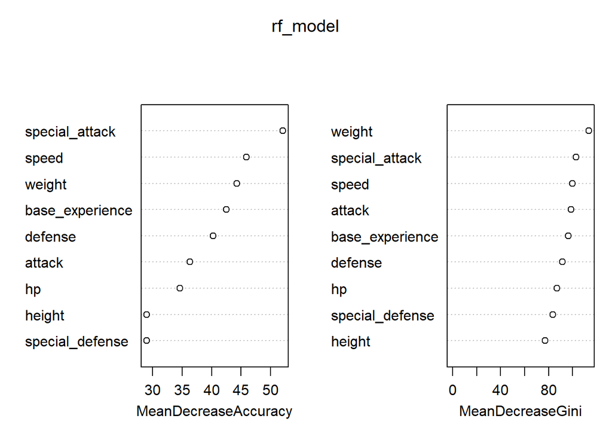

```r
varImpPlot(rf_model)
```

Model 3: KNN

```r
train_x <- train %>%
  select(hp, attack, defense, special_attack, special_defense, speed, height, weight, base_experience)

test_x <- test %>%
  select(hp, attack, defense, special_attack, special_defense, speed, height, weight, base_experience)

train_x_scaled <- scale(train_x)

test_x_scaled <- scale(
  test_x,
  center = attr(train_x_scaled, "scaled:center"),
  scale = attr(train_x_scaled, "scaled:scale")
)

knn_pred <- knn(
  train = train_x_scaled,
  test = test_x_scaled,
  cl = train$primary_type,
  k = 5
)

knn_cm <- confusionMatrix(knn_pred, test$primary_type)
knn_cm
```

```
## Confusion Matrix and Statistics
##
##           Reference
## Prediction bug dark dragon electric fairy fighting fire flying ghost grass
##   bug        6    2      1        1     0        1    3      0     0     1
##   dark       0    0      0        2     0        1    0      0     3     0
##   dragon     0    3      6        0     0        0    0      0     0     1
##   electric   4    1      0       10     1        1    3      0     3     2
##   fairy      0    0      0        0     1        0    0      0     0     1
##   fighting   0    0      1        1     0        4    0      0     0     3
##   fire       2    3      0        1     0        0   10      0     0     4
##   flying     1    0      0        0     0        0    0      1     0     0
##   ghost      1    0      0        0     1        0    0      0     4     3
##   grass      6    1      1        2     0        1    5      0     0     4
##   ground     1    0      0        0     0        2    0      0     1     0
##   ice        0    0      1        1     0        0    0      0     0     1
##   normal     1    1      2        2     0        2    1      1     0     3
##   poison     1    0      0        2     0        1    0      0     0     1
##   psychic    1    2      0        1     2        0    0      0     1     1
##   rock       2    2      1        0     0        4    0      0     2     1
##   steel      0    0      0        0     1        0    0      0     0     0
##   water      1    2      2        5     3        0    2      1     1     9
##           Reference
## Prediction ground ice normal poison psychic rock steel water
##   bug           2   1      3      1       2    3     4     2
##   dark          0   0      2      0       1    0     2     3
##   dragon        1   0      2      0       2    1     0     2
##   electric      0   1      1      3       3    0     0     4
##   fairy         1   0      0      0       1    0     0     0
##   fighting      0   0      2      1       0    1     0     1
##   fire          1   0      0      0       2    0     2     3
##   flying        1   0      1      0       0    0     0     0
##   ghost         1   1      1      2       1    1     1     1
##   grass         0   2      2      1       4    5     1     4
##   ground        2   1      0      1       0    4     0     1
##   ice           0   0      0      0       0    1     0     0
##   normal        2   0     14      4       0    0     0     9
##   poison        1   1      2      0       0    0     1     4
##   psychic       0   0      0      0       5    0     0     3
##   rock          0   0      2      1       1    4     2     2
```

[output cut: 46 more lines]

```
## Pos Pred Value             0.33333       0.00000        0.31250     0.16667
## Neg Pred Value             0.92035       0.95913        0.94795     0.94398
## Prevalence                 0.10761       0.03937        0.06299     0.06299
## Detection Rate             0.03675       0.00000        0.01312     0.01050
## Detection Prevalence       0.11024       0.03675        0.04199     0.06299
## Balanced Accuracy          0.62956       0.48087        0.58876     0.55532
##                      Class: steel Class: water
## Sensitivity               0.00000       0.1702
## Specificity               0.98365       0.8653
## Pos Pred Value            0.00000       0.1509
## Neg Pred Value            0.96267       0.8811
## Prevalence                0.03675       0.1234
## Detection Rate            0.00000       0.0210
## Detection Prevalence      0.01575       0.1391
## Balanced Accuracy         0.49183       0.5177
```

Model 4: Neural Network

```r
set.seed(123)

nn_model <- nnet(
  primary_type ~ hp + attack + defense + special_attack + special_defense + speed + height + weight + base_experience,
  data = train,
  size = 5,
  maxit = 500,
  trace = FALSE
)

nn_pred <- predict(nn_model, test, type = "class")
nn_pred <- as.factor(nn_pred)

nn_cm <- confusionMatrix(nn_pred, test$primary_type)
nn_cm
```

```
## Confusion Matrix and Statistics
##
##           Reference
## Prediction bug dark dragon electric fairy fighting fire flying ghost grass
##   bug        0    0      0        0     0        0    0      0     0     0
##   dark       0    0      0        0     0        0    0      0     0     0
##   dragon     0    0      0        0     0        0    0      0     0     0
##   electric   0    0      0        0     0        0    0      0     0     0
##   fairy      0    0      0        1     1        0    0      0     2     0
##   fighting   0    0      0        0     0        0    0      0     0     0
##   fire       0    0      0        0     0        0    0      0     0     0
##   flying     0    0      0        0     0        0    0      0     0     0
##   ghost      0    1      0        1     0        0    0      0     1     0
##   grass      0    0      0        0     0        0    0      0     0     0
##   ground     0    0      0        0     0        0    0      0     0     0
##   ice        0    0      0        0     0        0    0      0     0     0
##   normal     0    0      0        0     0        0    0      0     0     0
##   poison     0    0      0        0     0        0    0      0     0     0
##   psychic    0    0      0        0     0        0    0      0     0     0
##   rock       0    0      0        0     0        0    0      0     0     0
##   steel      0    0      0        0     0        0    0      0     0     0
##   water     27   16     15       26     8       17   24      3    12    35
##           Reference
## Prediction ground ice normal poison psychic rock steel water
##   bug           0   0      0      0       0    0     0     0
##   dark          0   0      0      0       0    0     0     0
##   dragon        0   0      0      0       0    0     0     0
##   electric      0   0      0      0       0    0     0     0
##   fairy         0   0      0      0       0    0     0     0
##   fighting      0   0      0      0       0    0     0     0
##   fire          0   0      0      0       0    0     0     0
##   flying        0   0      0      0       0    0     0     0
##   ghost         0   0      0      0       1    0     0     0
##   grass         0   0      0      0       0    0     0     0
##   ground        0   0      0      0       0    0     0     0
##   ice           0   0      0      0       0    0     0     0
##   normal        0   0      0      0       0    0     0     0
##   poison        0   0      0      0       0    0     0     0
##   psychic       0   0      0      0       0    0     0     0
##   rock          0   0      0      0       0    0     0     0
```

[output cut: 46 more lines]

```
## Pos Pred Value                 NaN           NaN            NaN         NaN
## Neg Pred Value              0.8924       0.96063        0.93701     0.93701
## Prevalence                  0.1076       0.03937        0.06299     0.06299
## Detection Rate              0.0000       0.00000        0.00000     0.00000
## Detection Prevalence        0.0000       0.00000        0.00000     0.00000
## Balanced Accuracy           0.5000       0.50000        0.50000     0.50000
##                      Class: steel Class: water
## Sensitivity               0.00000      1.00000
## Specificity               1.00000      0.02395
## Pos Pred Value                NaN      0.12601
## Neg Pred Value            0.96325      1.00000
## Prevalence                0.03675      0.12336
## Detection Rate            0.00000      0.12336
## Detection Prevalence      0.00000      0.97900
## Balanced Accuracy         0.50000      0.51198
```

Results

```r
results <- data.frame(
  Model = c("Decision Tree", "Random Forest", "KNN", "Neural Network"),
  Accuracy = c(
    tree_cm$overall["Accuracy"],
    rf_cm$overall["Accuracy"],
    knn_cm$overall["Accuracy"],
    nn_cm$overall["Accuracy"]
  )
)

results
```

```
##            Model  Accuracy
## 1  Decision Tree 0.1784777
## 2  Random Forest 0.3490814
## 3            KNN 0.2073491
## 4 Neural Network 0.1286089
```

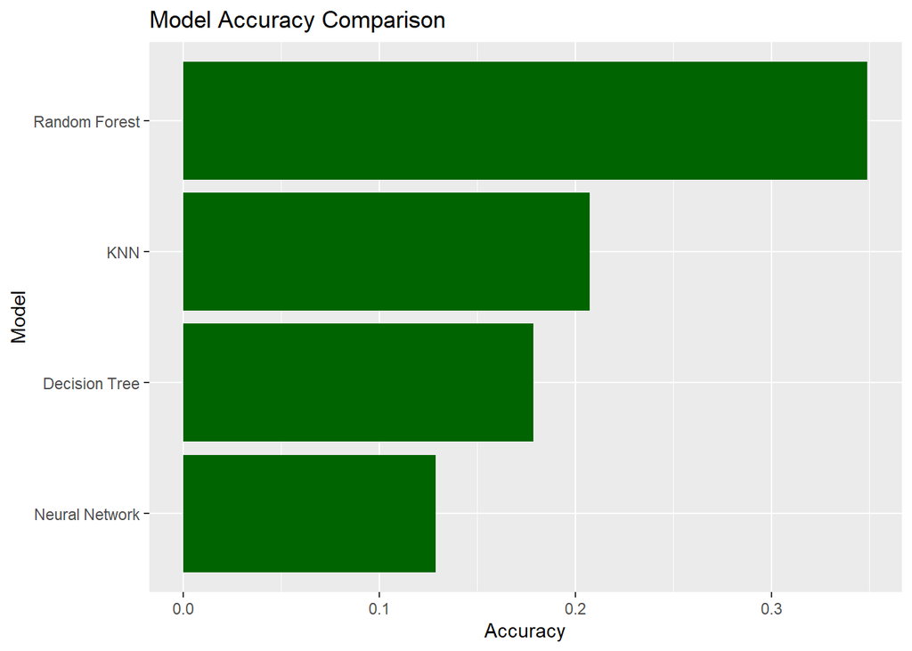

```r
ggplot(results, aes(x = reorder(Model, Accuracy), y = Accuracy)) +
  geom_col(fill = "darkgreen") +
  coord_flip() +
  labs(
    title = "Model Accuracy Comparison",
    x = "Model",
    y = "Accuracy"
  )
```

Conclusion

This project used machine learning to predict a Pokemon’s primary type based on its stats and physical characteristics.

The models compared were a decision tree, random forest, KNN, and neural network. Based on the accuracy results, the best-performing model was random forest.

The results show that Pokemon stats provide some useful information for predicting type, but there are limitations. Many Pokemon types overlap in their stats, which makes classification difficult.

Future improvements could include using more features, tuning model parameters, trying different neural network architectures, or simplifying the prediction problem by grouping similar Pokemon types together.